# Introduction to rosette simulation

Jingyou Rao

```r
library("rosace")
```

## Overview

We developed Rosette for simulating cell count data in growth or binding-based DMS screens. Rosette estimates summary statistics including sequencing count dispersion and variant score distributions from real data. You may use it to infer distributional properties from custom data and generate simulated data with desired noise effect, sequencing depth etc.

## Example

Again, we use the oct1 dataset as our example.

### Read Processed Rosace Object

```r
data("oct1_rosace")
key <- "1SM73"
type <- "growth"
```

### Create Naive Score

Rosette will learn the distributional properties of variant scores from score estimates. The score estimates can be naive (e.g. simple linear regression) or more complicated (e.g. `rosace`)

```r
oct1_rosace <- runSLR(oct1_rosace, name = "1SM73_2", type = "Assay")
```

### Create Rosette Object

```r
rosette <- CreateRosetteObject(object = oct1_rosace,
                               score.name = "1SM73_2_SLR",
                               pos.col = "position", mut.col = "mutation",
                               ctrl.col = "type", ctrl.name = "synonymous",
                               project.name = "1SM73_2_SLR")
```

### Generate Summary Statistics

#### Dispersion

Two dispersion parameters, dispersion of the sequencing count and dispersion of the variant library, are calculated from raw count. The former measures how much variability in variant representation there is before and during sequencing, and the later measures how much variability in variant representation there is before the cell selection. The dispersion parameters are automatically inferred when “CreateRosetteObject” is called.

```r
rosette@disp
```

```
## [1] 10.31088
```

```r
rosette@disp.start
```

```
## [1] 8.114383
```

#### Mutant Group Label

To account for similar functional effects among mutants (substitutions, insertions, or deletions of amino acids), we categorized them into mutant groups using hierarchical clustering.

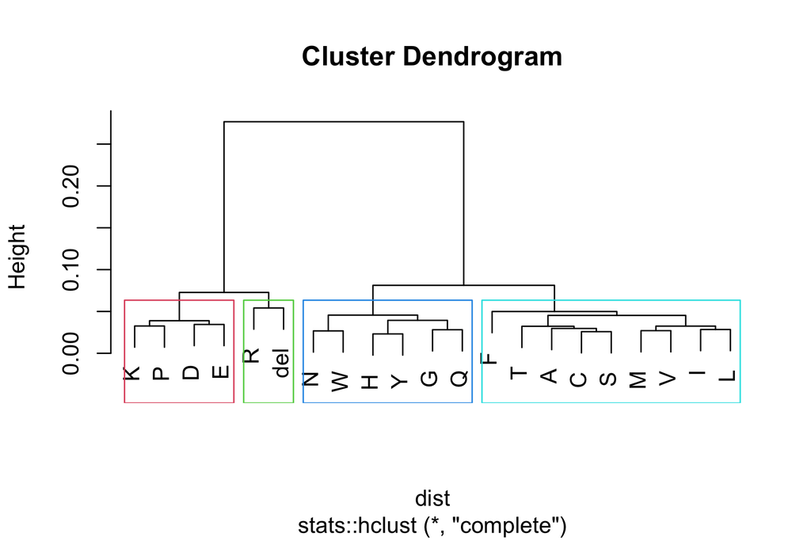

```r
hclust <- HclustMutant(rosette, save.plot = FALSE)
rosette <- GenMutLabel(rosette, hclust = hclust, Gmut = 4, save.plot = FALSE)
```

#### Variant Group Label

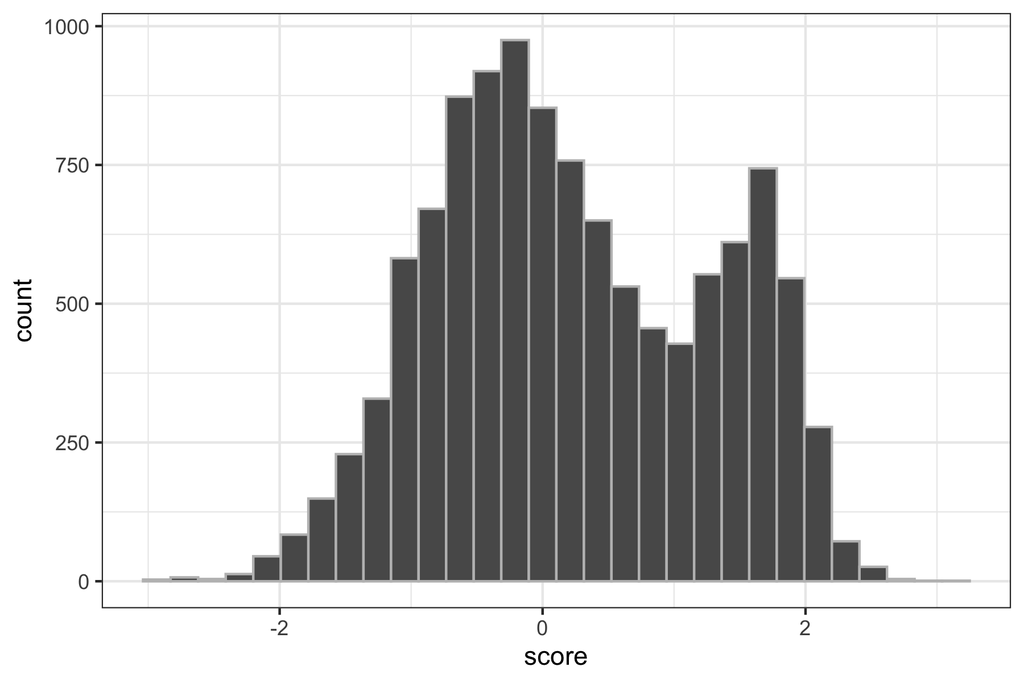

```r
PlotScoreHist(rosette, var.group = FALSE, mut.group = FALSE)
```

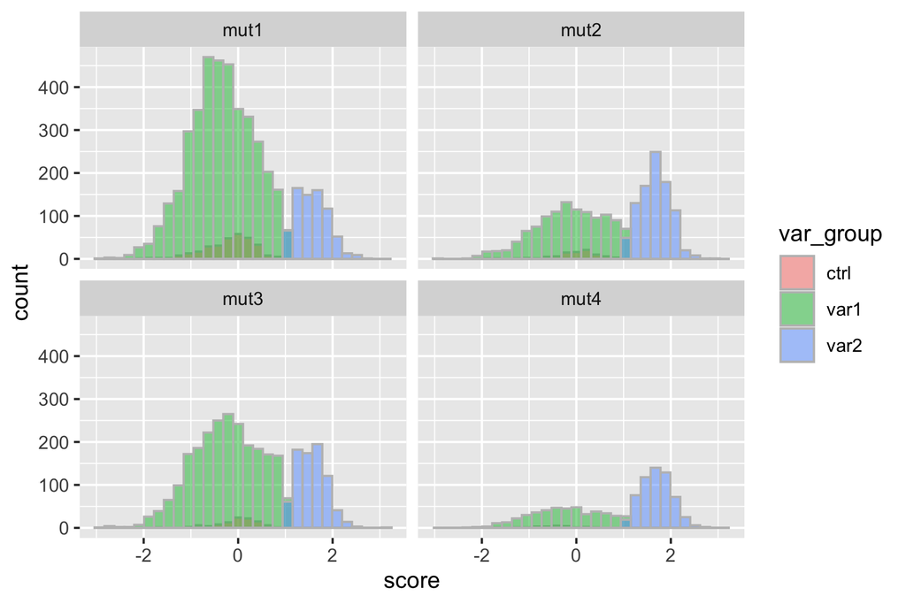

```r
rosette <- GenVarLabel(rosette, Gvar = 2)
PlotScoreHist(rosette, var.group = TRUE, mut.group = TRUE)
```

#### Weight of variant group within mutant group

Then, infer the distribution for the number of variants within each variant group and mutant group at each position. ‘pos.missing’ specifies the percentage of missing variants allowed at each position.

```r
rosette <- PMVCountDist(rosette, pos.missing = 0.2)
```

### Create config for simulation

Next, create a config file with other user defined properties for simulation, such as the number of rounds and replicates, experimental type (growth or binding), wild-type effect (binding) or doubling rate (growth), sequencing depth, shrinkage factor for library or sequencing dispersion, and simulation mode (clean or with replication error).

```r
cfg <- CreateConfig(rosette,
                    n.sim = 2, save.sim = "../tests/results/sim", type.sim = "growth",
                    n.rep = 3, n.round = 3,
                    null.var.group = 'var1', wt.effect = -2,
                    seq.shrink = 1.2, seq.depth = 100,
                    lib.shrink = 2,
                    var.shrink = 1, pos.flag = TRUE,
                    mode.sim = "clean")
```

### Run simulation

Finally, run the simulation with desired output format.

```r
runRosette(config = cfg, save.tsv = TRUE, save.rosace = TRUE, save.enrich2 = TRUE)
```